[figure not shown]

[figure not shown]

# s.XIX-XX | Pizarrón: única herramienta del aula

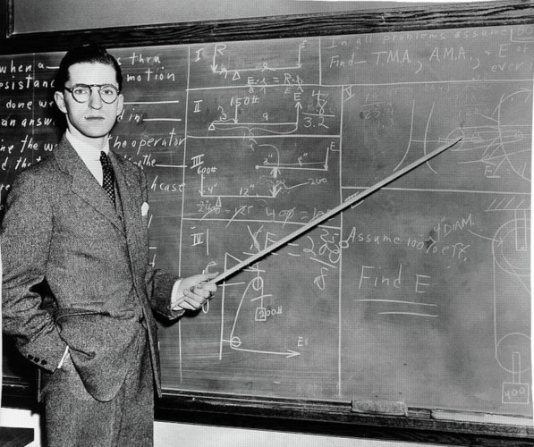

# s.XXI | Computadora: ¿para *diapositivas*?

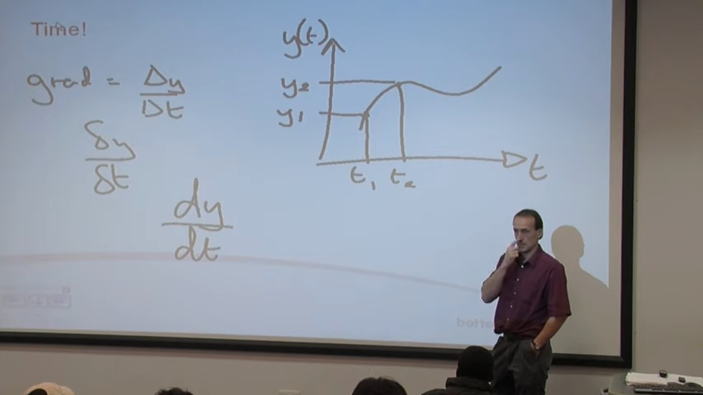

# Jupyter: un mejor uso de la computadora

es una interfaz interactiva de *cuadernos* basados en web para desplegar:

- Textos, figuras, multimedia y ecuaciones en nomenclatura estandarizada
- **Código**: cálculo simbólico, graficación y simulación numérica
  - **reutilizable**: el dado en clase se adapta para resolver ejercicios

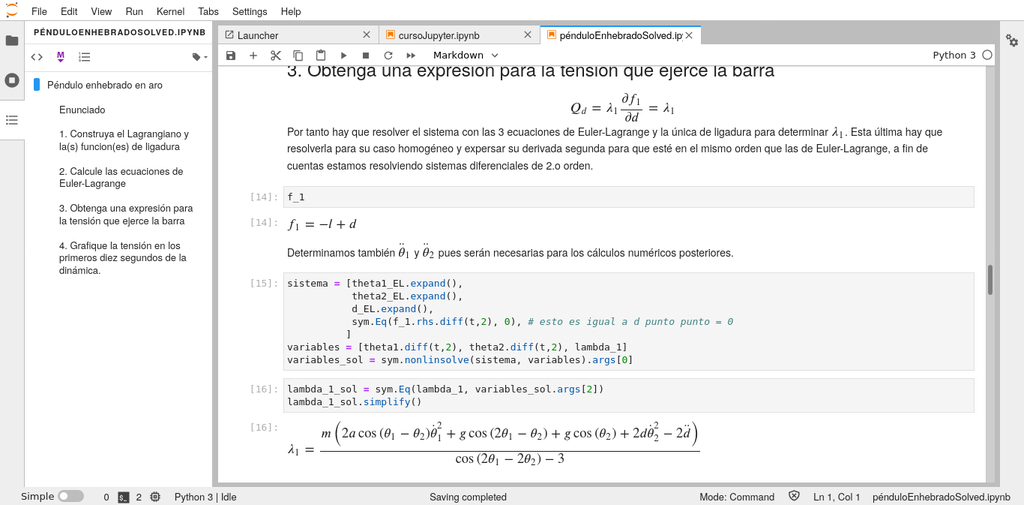

# Mecánica General en el DIIT - UNLaM

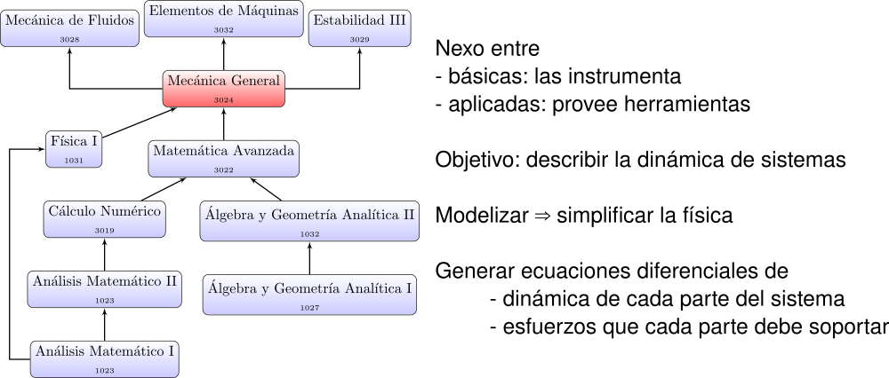

## Clase 1 | Una clara notación matemática

- La nomenclatura $\LaTeX$ está estandarizada por la American Mathematical Society

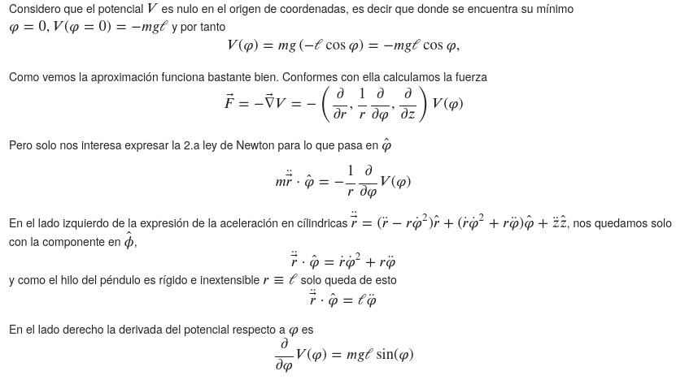

## Gráficos precisos y reproducibles

- Se hace explícito el código Python de graficación para incentivar la experimentación

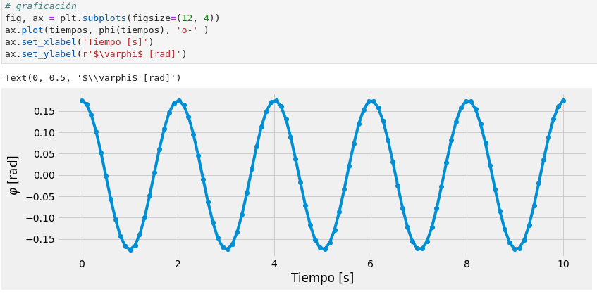

## Clase 3 | Cálculo simbólico

- Los alumnos ya aprobaron sus cursos de análisis y álgebra.
  - El foco está en aplicar tales herramientas.

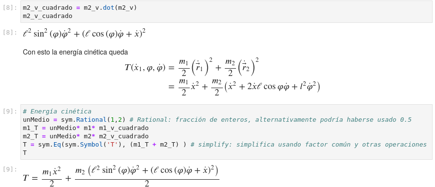

## Clase 4 | Ecuaciones de la dinámica

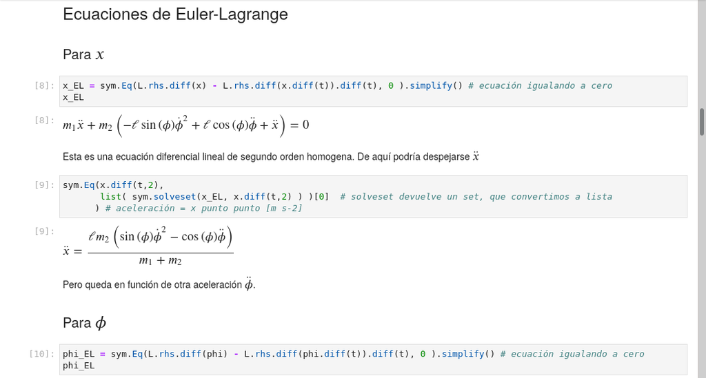

## Resolución automática de los cálculos

- Los cálculos engorrosos no concentran la atención del alumno
- Su complejidad no limita que sistema mecánico es analizable

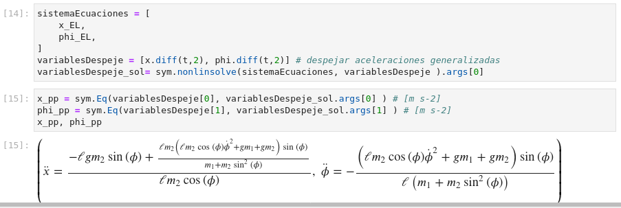

## Clase 5 | Cálculo numérico

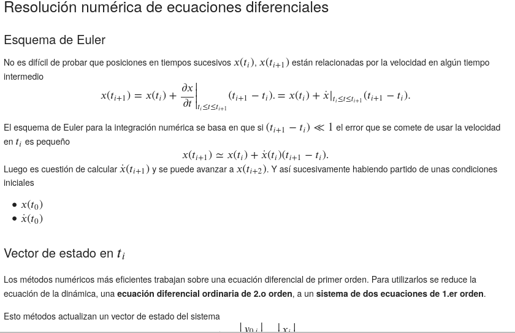

## Soluciones explícitas

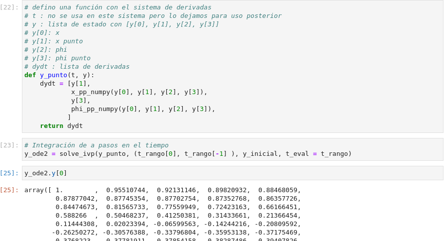

## Análisis de lo calculado

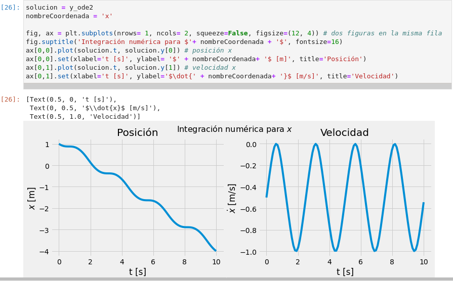

## Clase 7 | Sistemas más complejos

- Se **expande el código** de clases previas para estudiar:
  - oscilación y amortiguamiento
  - fuerzas que soportan diversas piezas
  - dinámica de cuerpos rígidos

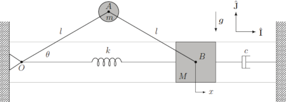

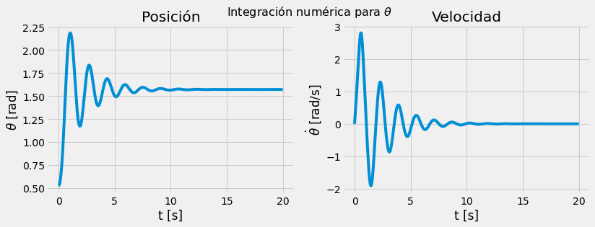

## Se llega a estudiar problemáticas realistas

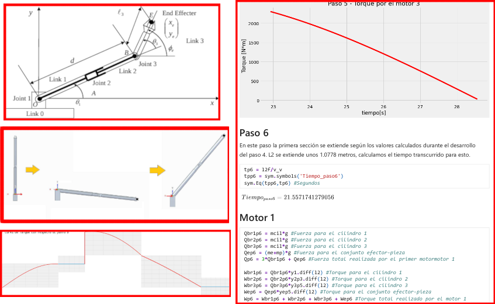

## Google Colaboratory: Jupyter gratuito en la web

- Alumnos solo requieren un navegador para trabajar en sus cuadernos
- Pueden colaborar en un mismo cuaderno en forma remota
- Docentes pueden editar o comentar el trabajo de estudiantes

[figure not shown]

## Examen y corrección

El examen es un ejercicio más, pero con horario de entrega

- Los alumnos envían el archivo del cuaderno
- En la devolución se intercalan correcciones tras las celdas con errores

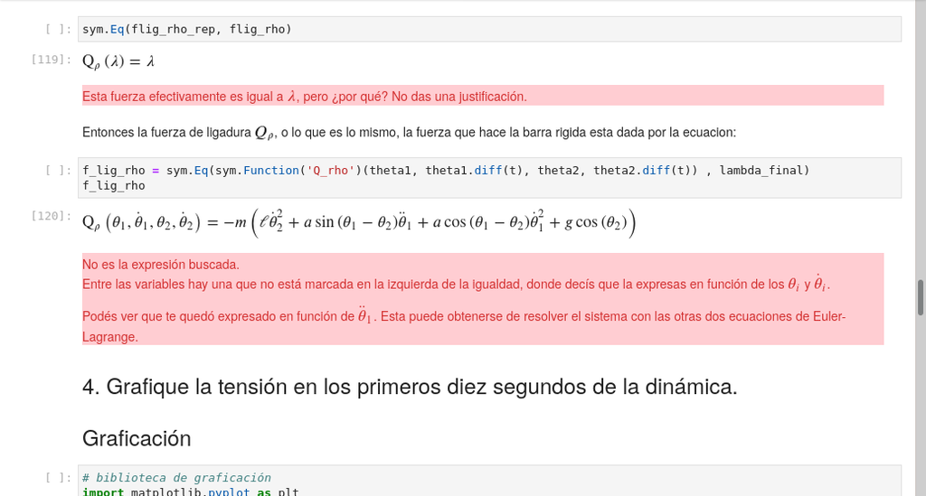

# Herramientas, competencias y habilidades

- Pizarrón + papel (s. XIX) $\Rightarrow$ Ejecutar código en línea (s. XXI)
  - **Sólo** resoluciones analíticas $\Rightarrow$ Explotar el **cálculo numérico**
  - Análisis **cualitativo** $\Rightarrow$ **Visualización cuantitativa** de la dinámica
  - Sistemas de complejidad **limitada** $\Rightarrow$ Dispositivos **realistas**
- Basado en recursos **en línea** $\Rightarrow$ Cursos remotos o de **aula híbrida**
  - contratados por la UNLaM: MS Teams (hay alternativas de software libre)
  - de acceso público y gratuito: GitHub, Google Colaboratory
- Con el trabajo con un **lenguaje de programación** los alumnos ganan experiencia en
  - competencias digitales $\Rightarrow$ alta demanda del sector productivo
  - trabajo remoto colaborativo $\Rightarrow$ deslocalización de la mano de obra
  - uso de software libre $\Rightarrow$ facilita el autoempleo con bajo capital

[figure not shown]